# Danish Kings

Christian

2025-07-3

The task here is to load your Danish Monarchs csv into R using the `tidyverse` toolkit, calculate and explore the kings’ duration of reign with pipes `%>%` in `dplyr` and plot it over time.

## Load the kings

Make sure to first create an `.Rproj` workspace with a `data/` folder where you place either your own dataset or the provided `kings.csv` dataset.

1. Look at the dataset that are you loading and check what its columns are separated by? (hint: open it in plain text editor to see)

2. Create a `kings` object in R with the different functions below and inspect the different outputs.
- `read.csv()`
- `read_csv()`
- `read.csv2()`
- `read_csv2()`

```r
library(tidyverse)
kings1 <- read.csv("data/danish_kings.csv")
glimpse(kings1)
```

```
## Rows: 54
## Columns: 1
## $ king_id.name.nickname.number.birth_year.birth_month.birth_day.death_year.death_month.death_day.reign_start_year.reign_start_month.reign_start_day.reign_end_year.reign_end_month.reign_end_day.sec_reign_start.sec_reign_end <chr> …
```

```r
kings2 <- read_csv("data/danish_kings.csv")
glimpse(kings2)
```

```
## Rows: 54
## Columns: 1
## $ `king_id;name;nickname;number;birth_year;birth_month;birth_day;death_year;death_month;death_day;reign_start_year;reign_start_month;reign_start_day;reign_end_year;reign_end_month;reign_end_day;sec_reign_start;sec_reign_end` <chr> …
```

```r
kings3 <- read.csv2("data/danish_kings.csv")
glimpse(kings3)
```

```
## Rows: 54
## Columns: 18
## $ king_id           <int> 1, 2, 3, 4, 5, 6, 7, 8, 9, 10, 11, 12, 13, 14, 15, 1…
## $ name              <chr> "Gorm", "Harald", "Svend", "Harald", "Knud", "Knud",…
## $ nickname          <chr> "\"den gamle\" ", "Blaatand", "Tveskaeg", "Svensen",…
## $ number            <int> NA, 1, 1, 2, 2, 3, 1, 2, 3, 4, 1, 1, NA, 2, 3, 3, 5,…
## $ birth_year        <int> NA, NA, NA, NA, 995, 1020, 1024, NA, NA, NA, NA, 105…
## $ birth_month       <int> NA, NA, NA, NA, NA, NA, NA, NA, NA, NA, NA, NA, NA, …
## $ birth_day         <int> NA, NA, NA, NA, NA, NA, NA, NA, NA, NA, NA, NA, NA, …
## $ death_year        <int> 958, 987, 1014, 1018, 1035, 1042, 1047, 1076, 1080, …
## $ death_month       <int> NA, NA, NA, NA, NA, NA, NA, 4, NA, 7, NA, NA, NA, 7,…
## $ death_day         <int> NA, NA, NA, NA, NA, NA, NA, 28, NA, 10, NA, NA, NA, …
## $ reign_start_year  <int> NA, 958, 987, 1014, 1018, 1035, 1042, 1047, 1074, 10…
## $ reign_start_month <int> NA, NA, NA, NA, NA, NA, NA, NA, NA, NA, 7, NA, NA, N…
## $ reign_start_day   <int> NA, NA, NA, NA, NA, NA, NA, NA, NA, NA, 10, NA, NA, …
## $ reign_end_year    <int> 958, 987, 1014, 1018, 1035, 1042, 1047, 1074, 1080, …
## $ reign_end_month   <int> NA, NA, NA, NA, NA, NA, NA, NA, NA, NA, NA, NA, NA, …
## $ reign_end_day     <int> NA, NA, NA, NA, NA, NA, NA, NA, NA, NA, NA, NA, NA, …
## $ sec_reign_start   <int> NA, NA, NA, NA, NA, NA, NA, NA, NA, NA, NA, NA, NA, …
## $ sec_reign_end     <int> NA, NA, NA, NA, NA, NA, NA, NA, NA, NA, NA, NA, NA, …
```

```r
kings4 <- read_csv2( "data/danish_kings.csv")
```

```
## ℹ Using "','" as decimal and "'.'" as grouping mark. Use `read_delim()` for more control.
```

```r
glimpse(kings4)
```

```
## Rows: 54
## Columns: 18
## $ king_id           <dbl> 1, 2, 3, 4, 5, 6, 7, 8, 9, 10, 11, 12, 13, 14, 15, 1…
## $ name              <chr> "Gorm", "Harald", "Svend", "Harald", "Knud", "Knud",…
## $ nickname          <chr> "\"den gamle\"", "Blaatand", "Tveskaeg", "Svensen", …
## $ number            <dbl> NA, 1, 1, 2, 2, 3, 1, 2, 3, 4, 1, 1, NA, 2, 3, 3, 5,…
## $ birth_year        <dbl> NA, NA, NA, NA, 995, 1020, 1024, NA, NA, NA, NA, 105…
## $ birth_month       <dbl> NA, NA, NA, NA, NA, NA, NA, NA, NA, NA, NA, NA, NA, …
## $ birth_day         <dbl> NA, NA, NA, NA, NA, NA, NA, NA, NA, NA, NA, NA, NA, …
## $ death_year        <dbl> 958, 987, 1014, 1018, 1035, 1042, 1047, 1076, 1080, …
## $ death_month       <dbl> NA, NA, NA, NA, NA, NA, NA, 4, NA, 7, NA, NA, NA, 7,…
## $ death_day         <dbl> NA, NA, NA, NA, NA, NA, NA, 28, NA, 10, NA, NA, NA, …
## $ reign_start_year  <dbl> NA, 958, 987, 1014, 1018, 1035, 1042, 1047, 1074, 10…
## $ reign_start_month <dbl> NA, NA, NA, NA, NA, NA, NA, NA, NA, NA, 7, NA, NA, N…
## $ reign_start_day   <dbl> NA, NA, NA, NA, NA, NA, NA, NA, NA, NA, 10, NA, NA, …
## $ reign_end_year    <dbl> 958, 987, 1014, 1018, 1035, 1042, 1047, 1074, 1080, …
## $ reign_end_month   <dbl> NA, NA, NA, NA, NA, NA, NA, NA, NA, NA, NA, NA, NA, …
## $ reign_end_day     <dbl> NA, NA, NA, NA, NA, NA, NA, NA, NA, NA, NA, NA, NA, …
## $ sec_reign_start   <dbl> NA, NA, NA, NA, NA, NA, NA, NA, NA, NA, NA, NA, NA, …
## $ sec_reign_end     <dbl> NA, NA, NA, NA, NA, NA, NA, NA, NA, NA, NA, NA, NA, …
```

Answer: 1. Which of these functions is a `tidyverse` function? Read data with it below into a `kings` object 2. What is the result of running `class()` on the `kings` object created with a tidyverse function. 3. How many columns does the object have when created with these different functions? 4. Show the dataset so that we can see how R interprets each column

```r
# COMPLETE THE BLANKS BELOW WITH YOUR CODE, then turn the 'eval' flag in this chunk to TRUE.
library(tidyverse)

## here i have defined the correct way to read the data as kings with NA=na
kings <- read_csv2("data/danish_kings.csv", na = "NA")
```

```
## ℹ Using "','" as decimal and "'.'" as grouping mark. Use `read_delim()` for more control.
```

```r
glimpse(kings)
```

```
## Rows: 54
## Columns: 18
## $ king_id           <dbl> 1, 2, 3, 4, 5, 6, 7, 8, 9, 10, 11, 12, 13, 14, 15, 1…
## $ name              <chr> "Gorm", "Harald", "Svend", "Harald", "Knud", "Knud",…
## $ nickname          <chr> "\"den gamle\"", "Blaatand", "Tveskaeg", "Svensen", …
## $ number            <dbl> NA, 1, 1, 2, 2, 3, 1, 2, 3, 4, 1, 1, NA, 2, 3, 3, 5,…
## $ birth_year        <dbl> NA, NA, NA, NA, 995, 1020, 1024, NA, NA, NA, NA, 105…
## $ birth_month       <dbl> NA, NA, NA, NA, NA, NA, NA, NA, NA, NA, NA, NA, NA, …
## $ birth_day         <dbl> NA, NA, NA, NA, NA, NA, NA, NA, NA, NA, NA, NA, NA, …
## $ death_year        <dbl> 958, 987, 1014, 1018, 1035, 1042, 1047, 1076, 1080, …
## $ death_month       <dbl> NA, NA, NA, NA, NA, NA, NA, 4, NA, 7, NA, NA, NA, 7,…
## $ death_day         <dbl> NA, NA, NA, NA, NA, NA, NA, 28, NA, 10, NA, NA, NA, …
## $ reign_start_year  <dbl> NA, 958, 987, 1014, 1018, 1035, 1042, 1047, 1074, 10…
## $ reign_start_month <dbl> NA, NA, NA, NA, NA, NA, NA, NA, NA, NA, 7, NA, NA, N…
## $ reign_start_day   <dbl> NA, NA, NA, NA, NA, NA, NA, NA, NA, NA, 10, NA, NA, …
## $ reign_end_year    <dbl> 958, 987, 1014, 1018, 1035, 1042, 1047, 1074, 1080, …
## $ reign_end_month   <dbl> NA, NA, NA, NA, NA, NA, NA, NA, NA, NA, NA, NA, NA, …
## $ reign_end_day     <dbl> NA, NA, NA, NA, NA, NA, NA, NA, NA, NA, NA, NA, NA, …
## $ sec_reign_start   <dbl> NA, NA, NA, NA, NA, NA, NA, NA, NA, NA, NA, NA, NA, …
## $ sec_reign_end     <dbl> NA, NA, NA, NA, NA, NA, NA, NA, NA, NA, NA, NA, NA, …
```

```r
class(kings1)
```

```
## [1] "data.frame"
```

```r
class(kings2)
```

```
## [1] "spec_tbl_df" "tbl_df"      "tbl"         "data.frame"
```

```r
class(kings3)
```

```
## [1] "data.frame"
```

```r
class(kings4)
```

```
## [1] "spec_tbl_df" "tbl_df"      "tbl"         "data.frame"
```

```r
ncol(kings1)
```

```
## [1] 1
```

```r
ncol(kings2)
```

```
## [1] 1
```

```r
ncol(kings3)
```

```
## [1] 18
```

```r
ncol(kings4)
```

```
## [1] 18
```

```r
head(kings1)
```

```
##   king_id.name.nickname.number.birth_year.birth_month.birth_day.death_year.death_month.death_day.reign_start_year.reign_start_month.reign_start_day.reign_end_year.reign_end_month.reign_end_day.sec_reign_start.sec_reign_end
## 1                                                                                                                                                           1;Gorm;"den gamle" ;NA;NA;NA;NA;958;NA;NA;NA;NA;NA;958;NA;NA;NA;NA
## 2                                                                                                                                                             2;Harald;Blaatand;1;NA;NA;NA;987;NA;NA;958;NA;NA;987;NA;NA;NA;NA
## 3                                                                                                                                                            3;Svend;Tveskaeg;1;NA;NA;NA;1014;NA;NA;987;NA;NA;1014;NA;NA;NA;NA
## 4                                                                                                                                                           4;Harald;Svensen;2;NA;NA;NA;1018;NA;NA;1014;NA;NA;1018;NA;NA;NA;NA
## 5                                                                                                                                                        5;Knud;"den store";2;995;NA;NA;1035;NA;NA;1018;NA;NA;1035;NA;NA;NA;NA
## 6                                                                                                                                                         6;Knud;Hardeknud;3;1020;NA;NA;1042;NA;NA;1035;NA;NA;1042;NA;NA;NA;NA
```

```r
head(kings2)
```

```
## # A tibble: 6 × 1
##   king_id;name;nickname;number;birth_year;birth_month;birth_day;death_year;dea…¹
##   <chr>
## 1 "1;Gorm;\"\"\"den gamle\"\" \";NA;NA;NA;NA;958;NA;NA;NA;NA;NA;958;NA;NA;NA;NA"
## 2 "2;Harald;Blaatand;1;NA;NA;NA;987;NA;NA;958;NA;NA;987;NA;NA;NA;NA"
## 3 "3;Svend;Tveskaeg;1;NA;NA;NA;1014;NA;NA;987;NA;NA;1014;NA;NA;NA;NA"
## 4 "4;Harald;Svensen;2;NA;NA;NA;1018;NA;NA;1014;NA;NA;1018;NA;NA;NA;NA"
## 5 "5;Knud;\"\"\"den store\"\"\";2;995;NA;NA;1035;NA;NA;1018;NA;NA;1035;NA;NA;NA…
## 6 "6;Knud;Hardeknud;3;1020;NA;NA;1042;NA;NA;1035;NA;NA;1042;NA;NA;NA;NA"
## # ℹ abbreviated name:
## #   ¹`king_id;name;nickname;number;birth_year;birth_month;birth_day;death_year;death_month;death_day;reign_start_year;reign_start_month;reign_start_day;reign_end_year;reign_end_month;reign_end_day;sec_reign_start;sec_reign_end`
```

```r
head(kings3)
```

```
##   king_id   name     nickname number birth_year birth_month birth_day
## 1       1   Gorm "den gamle"      NA         NA          NA        NA
## 2       2 Harald     Blaatand      1         NA          NA        NA
## 3       3  Svend     Tveskaeg      1         NA          NA        NA
## 4       4 Harald      Svensen      2         NA          NA        NA
## 5       5   Knud  "den store"      2        995          NA        NA
## 6       6   Knud    Hardeknud      3       1020          NA        NA
##   death_year death_month death_day reign_start_year reign_start_month
## 1        958          NA        NA               NA                NA
## 2        987          NA        NA              958                NA
## 3       1014          NA        NA              987                NA
## 4       1018          NA        NA             1014                NA
## 5       1035          NA        NA             1018                NA
## 6       1042          NA        NA             1035                NA
##   reign_start_day reign_end_year reign_end_month reign_end_day sec_reign_start
## 1              NA            958              NA            NA              NA
## 2              NA            987              NA            NA              NA
## 3              NA           1014              NA            NA              NA
## 4              NA           1018              NA            NA              NA
## 5              NA           1035              NA            NA              NA
## 6              NA           1042              NA            NA              NA
##   sec_reign_end
## 1            NA
## 2            NA
## 3            NA
## 4            NA
## 5            NA
## 6            NA
```

```r
head(kings4)
```

```
## # A tibble: 6 × 18
##   king_id name   nickname     number birth_year birth_month birth_day death_year
##     <dbl> <chr>  <chr>         <dbl>      <dbl>       <dbl>     <dbl>      <dbl>
## 1       1 Gorm   "\"den gaml…     NA         NA          NA        NA        958
## 2       2 Harald "Blaatand"        1         NA          NA        NA        987
## 3       3 Svend  "Tveskaeg"        1         NA          NA        NA       1014
## 4       4 Harald "Svensen"         2         NA          NA        NA       1018
## 5       5 Knud   "\"den stor…      2        995          NA        NA       1035
## 6       6 Knud   "Hardeknud"       3       1020          NA        NA       1042
## # ℹ 10 more variables: death_month <dbl>, death_day <dbl>,
## #   reign_start_year <dbl>, reign_start_month <dbl>, reign_start_day <dbl>,
## #   reign_end_year <dbl>, reign_end_month <dbl>, reign_end_day <dbl>,
## #   sec_reign_start <dbl>, sec_reign_end <dbl>
```

## Calculate the duration of reign for all the kings in your table

You can calculate the duration of reign in years with `mutate` function by subtracting the equivalents of your `startReign` from `endReign` columns and writing the result to a new column called `duration`. But first you need to check a few things:

- Is your data messy? Fix it before re-importing to R
- Do your start and end of reign columns contain NAs? Choose the right strategy to deal with them: `na.omit()`, `na.rm=TRUE`, `!is.na()`

Create a new column called `duration` in the kings dataset, utilizing the `mutate()` function from tidyverse. Check with your group to brainstorm the options.

```r
library(tidyverse)

# Inspect the Data
summary(kings)
```

```
##     king_id          name             nickname             number
##  Min.   : 1.00   Length:54          Length:54          Min.   : 1.00
##  1st Qu.:14.25   Class :character   Class :character   1st Qu.: 2.00
##  Median :27.50   Mode  :character   Mode  :character   Median : 3.00
##  Mean   :27.50                                         Mean   : 3.86
##  3rd Qu.:40.75                                         3rd Qu.: 5.75
##  Max.   :54.00                                         Max.   :10.00
##                                                        NA's   :4
##    birth_year    birth_month       birth_day       death_year    death_month
##  Min.   : 995   Min.   : 1.000   Min.   : 1.00   Min.   : 958   Min.   : 1.00
##  1st Qu.:1249   1st Qu.: 4.000   1st Qu.: 6.00   1st Qu.:1136   1st Qu.: 2.00
##  Median :1455   Median : 6.000   Median :12.00   Median :1331   Median : 4.00
##  Mean   :1473   Mean   : 7.048   Mean   :13.52   Mean   :1396   Mean   : 4.88
##  3rd Qu.:1723   3rd Qu.: 9.000   3rd Qu.:18.00   3rd Qu.:1654   3rd Qu.: 8.00
##  Max.   :1968   Max.   :28.000   Max.   :31.00   Max.   :1972   Max.   :12.00
##  NA's   :13     NA's   :33       NA's   :33      NA's   :2      NA's   :29
##    death_day     reign_start_year reign_start_month reign_start_day
##  Min.   : 1.00   Min.   : 958     Min.   : 1.00     Min.   : 3.00
##  1st Qu.:10.00   1st Qu.:1137     1st Qu.: 1.75     1st Qu.:12.75
##  Median :15.00   Median :1340     Median : 6.00     Median :14.50
##  Mean   :16.56   Mean   :1407     Mean   : 5.50     Mean   :17.40
##  3rd Qu.:25.00   3rd Qu.:1670     3rd Qu.: 8.00     3rd Qu.:25.50
##  Max.   :29.00   Max.   :2024     Max.   :12.00     Max.   :29.00
##  NA's   :29      NA's   :1        NA's   :34        NA's   :34
##  reign_end_year reign_end_month reign_end_day   sec_reign_start sec_reign_end
##  Min.   : 958   Min.   : 1.00   Min.   : 1.00   Min.   :1330    Min.   :1332
##  1st Qu.:1137   1st Qu.: 1.00   1st Qu.: 9.75   1st Qu.:1330    1st Qu.:1332
##  Median :1330   Median : 3.50   Median :14.00   Median :1330    Median :1332
##  Mean   :1407   Mean   : 4.30   Mean   :14.60   Mean   :1330    Mean   :1332
##  3rd Qu.:1670   3rd Qu.: 5.75   3rd Qu.:20.00   3rd Qu.:1330    3rd Qu.:1332
##  Max.   :2024   Max.   :12.00   Max.   :29.00   Max.   :1330    Max.   :1332
##  NA's   :1      NA's   :34      NA's   :34      NA's   :53      NA's   :53
```

```r
# Handle NA values
kings_clean <- kings %>%
  filter(!is.na(reign_start_year) & !is.na(reign_end_year))

# Calculate the duration of reign
kings_duration <- kings_clean %>%
  mutate(duration = reign_end_year - reign_start_year)

# Inspect the new dataset
head(kings_duration)
```

```
## # A tibble: 6 × 19
##   king_id name   nickname     number birth_year birth_month birth_day death_year
##     <dbl> <chr>  <chr>         <dbl>      <dbl>       <dbl>     <dbl>      <dbl>
## 1       2 Harald "Blaatand"        1         NA          NA        NA        987
## 2       3 Svend  "Tveskaeg"        1         NA          NA        NA       1014
## 3       4 Harald "Svensen"         2         NA          NA        NA       1018
## 4       5 Knud   "\"den stor…      2        995          NA        NA       1035
## 5       6 Knud   "Hardeknud"       3       1020          NA        NA       1042
## 6       7 Magnus "\"den gode…      1       1024          NA        NA       1047
## # ℹ 11 more variables: death_month <dbl>, death_day <dbl>,
## #   reign_start_year <dbl>, reign_start_month <dbl>, reign_start_day <dbl>,
## #   reign_end_year <dbl>, reign_end_month <dbl>, reign_end_day <dbl>,
## #   sec_reign_start <dbl>, sec_reign_end <dbl>, duration <dbl>
```

## Calculate the average duration of reign for all rulers

Do you remember how to calculate an average on a vector object? If not, review the last two lessons and remember that a column is basically a vector. So you need to subset your `kings` dataset to the `duration` column. If you subset it as a vector you can calculate average on it with `mean()` base-R function. If you subset it as a tibble, you can calculate average on it with `summarize()` tidyverse function. Try both ways!

- You first need to know how to select the relevant `duration` column. What are your options?
- Is your selected `duration` column a tibble or a vector? The `mean()` function can only be run on a vector. The `summarize()` function works on a tibble.
- Are you getting an error that there are characters in your column? Coerce your data to numbers with `as.numeric()`.
- Remember to handle NAs: `mean(X, na.rm=TRUE)`

```r
## here i use the function to find the average reign duraton
library(tidyverse)
average_duration <- kings_duration %>%
  summarise(mean_duration = mean(duration, na.rm = TRUE))
print(average_duration)
```

```
## # A tibble: 1 × 1
##   mean_duration
##           <dbl>
## 1          20.6
```

## How many and which kings enjoyed a longer-than-average duration of reign?

You have calculated the average duration above. Use it now to `filter()` the `duration` column in `kings` dataset. Display the result and also count the resulting rows with `count()`

```r
library(tidyverse)
average_duration1 <- mean(kings_duration$duration, na.rm = TRUE)

long_reining_kings <-  kings_duration %>%
  filter(duration > average_duration1) %>%
  select(name, duration) %>%
  print(n=Inf)
```

```
## # A tibble: 25 × 2
##    name      duration
##    <chr>        <dbl>
##  1 Harald          29
##  2 Svend           27
##  3 Svend           27
##  4 Niels           30
##  5 Valdemar        25
##  6 Valdemar        39
##  7 Erik            27
##  8 Erik            33
##  9 Valdemar        35
## 10 Margrete        25
## 11 Erik            47
## 12 Christian       33
## 13 Hans            31
## 14 Christian       23
## 15 Frederik        29
## 16 Christian       52
## 17 Frederik        22
## 18 Christian       29
## 19 Frederik        31
## 20 Christian       42
## 21 Frederik        31
## 22 Christian       43
## 23 Christian       35
## 24 Frederik        25
## 25 Magrethe        52
```

## How many days did the three longest-ruling monarchs rule?

- Sort kings by reign `duration` in the descending order. Select the three longest-ruling monarchs with the `slice()` function
- Use `mutate()` to create `Days` column where you calculate the total number of days they ruled
- BONUS: consider the transition year (with 366 days) in your calculation!

```r
kings_duration %>%
  arrange(desc(duration)) %>%
  slice(1:3) %>%
  mutate(Days = duration * 365 + floor(duration / 4)) %>%
  select(name, duration, Days)
```

```
## # A tibble: 3 × 3
##   name      duration  Days
##   <chr>        <dbl> <dbl>
## 1 Christian       52 18993
## 2 Magrethe        52 18993
## 3 Erik            47 17166
```

## Challenge: Plot the kings’ duration of reign through time

What is the long-term trend in the duration of reign among Danish monarchs? How does it relate to the historical violence trends ?

- Try to plot the duration of reign column in `ggplot` with `geom_point()` and `geom_smooth()`
- In order to peg the duration (which is between 1-99) somewhere to the x axis with individual centuries, I recommend creating a new column `midyear` by adding to `startYear` the product of `endYear` minus the `startYear` divided by two (`startYear + (endYear-startYear)/2`).
- Now you can plot the kings dataset, plotting `midyear` along the x axis and `duration` along y axis
- BONUS: add a title, nice axis labels to the plot and make the theme B&W and font bigger to make it nice and legible!

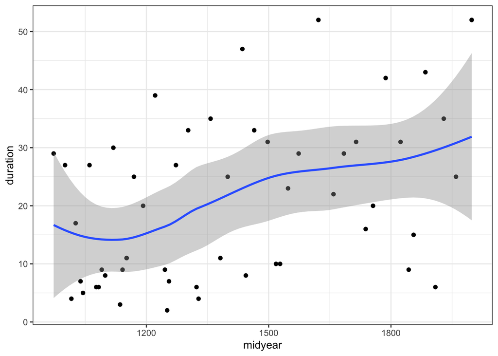

```r
library(tidyverse)
kings_midyear <- kings %>%
  mutate(midyear = (reign_start_year + reign_end_year) / 2) %>%
  mutate(duration = reign_end_year - reign_start_year)

kings_midyear %>%
  ggplot(aes(x = midyear , y = duration))+
  geom_point( aes(color = ))+
  geom_smooth()+
  theme_bw()
```

And to submit this rmarkdown, knit it into html. But first, clean up the code chunks, adjust the date, rename the author and change the `eval=FALSE` flag to `eval=TRUE` so your script actually generates an output. Well done!